# R Notebook

## Try executing this chunk by clicking the *Run* button within the chunk or by placing your cursor inside it and pressing *Ctrl+Shift+Enter*.

```r
library(ggplot2)
library(dplyr)
library(tidyverse)
library(ggrepel)
library(moderndive)
```

```r
yc<-read.csv("YC Plus.csv")
```

#Now let’s explore YC data in terms of geography, first we need to separate location in separate columns (city, country, continent)

```r
str(yc)
```

```
## 'data.frame':    2584 obs. of  23 variables:
##  $ Unicorn_Bin                           : int  0 0 0 0 0 0 1 1 0 1 ...
##  $ Name                                  : chr  "Copia" "Suiteness" "Astranis" "Shield Bio" ...
##  $ Count                                 : int  1 2 2 2 2 2 1 3 2 1 ...
##  $ Counts                                : int  NA NA NA NA NA NA 1 1 NA 1 ...
##  $ Transaction.Name                      : chr  "Seed Round - Copia" "Series A - Suiteness" "Seed Round - Astranis" "Seed Round - Shield Bio" ...
##  $ Funding.Type                          : chr  "Seed" "Series A" "Seed" "Seed" ...
##  $ Money.Raised.Currency..in.USD.        : int  3100000 5000000 120000 4100000 NA NA 120000 NA 2500000 120000 ...
##  $ Announced.Date                        : chr  "3/22/2016" "12/14/2016" "3/22/2016" "2/23/2017" ...
##  $ Funding.Stage                         : chr  "Seed" "Early Stage Venture" "Seed" "Seed" ...
##  $ Pre.Money.Valuation.Currency..in.USD. : num  NA NA NA NA NA NA NA NA NA NA ...
##  $ Description                           : chr  "Copia is the next-generation technology platform for food waste management." "Suiteness is a free-to-join hotel booking website connecting hotel rooms and suites." "Astranis is building small, low-cost telecommunications satellites." "Shield Bio - …
##  $ Categories                            : chr  "Analytics, Communities, Enterprise, Enterprise Software, Marketplace, SaaS, Sharing Economy, Sustainability, Waste Management" "Family, Hospitality, Hotel, Leisure, Reservations, Travel" "Aerospace, Internet, Telecommunications" "Biotechnology, Gen…
##  $ Location                              : chr  "San Francisco, California, United States, North America" "Oakland, California, United States, North America" "San Francisco, California, United States, North America" "San Jose, California, United States, North America" ...
##  $ Website                               : chr  "https://www.GoCopia.com/" "https://www.suiteness.com" "http://www.astranis.com/" "http://shieldbio.com" ...
##  $ Revenue.Range                         : chr  "$1M to $10M" "$1M to $10M" "$1M to $10M" "" ...
##  $ Total.Funding.Amount.Currency..in.USD.: num  4580000 6000000 13619998 12100000 16428315 ...
##  $ Funding.Status                        : chr  "Seed" "Early Stage Venture" "Early Stage Venture" "Early Stage Venture" ...
##  $ Number.of.Funding.Rounds              : int  2 3 7 2 5 3 2 4 1 3 ...
##  $ Lead.Investors                        : chr  "Structure Capital" "Bullpen Capital, Global Founders Capital" "" "Andreessen Horowitz" ...
##  $ Investor.Names                        : chr  "8VC, Alps Investing Holdings LLC, Chivas Venture, Cynthia Ringo, David Pottruck, Emerson Collective, Eucalyptus"| __truncated__ "AltaIR Capital, Bullpen Capital, David Hauser, FundersClub, Global Founders Capital, HVF Labs, Jared Ablon, Kim"| __tru…
##  $ Number.of.Investors                   : int  23 16 9 7 14 3 1 4 6 1 ...
##  $ Number.of.Partner.Investors           : int  10 2 NA 6 NA NA NA NA NA NA ...
##  $ Years_Transition_Unicorn              : num  NA NA NA NA NA NA 2.92 4.74 NA 4.06 ...
```

```r
yc<-yc%>%
 separate(Location, c("City", "State", "Country", "Continent"), ", ")
yc
```

| Unicorn_Bin | Name | Count | Counts | Transaction.Name | Funding.Type | Money.Raised.Currency..in.USD. | Announced.Date | Funding.Stage | Pre.Money.Valuation.Currency..in.USD. | Description | Categories | City | State | Country | Continent | Website | Revenue.Range | Total.Funding.Amount.Currency..in.USD. | Funding.Status | Number.of.Funding.Rounds | Lead.Investors | Investor.Names | Number.of.Investors | Number.of.Partner.Investors | Years_Transition_Unicorn |
| --- | --- | --- | --- | --- | --- | --- | --- | --- | --- | --- | --- | --- | --- | --- | --- | --- | --- | --- | --- | --- | --- | --- | --- | --- | --- |
| 0 | Copia | 1 | NA | Seed Round - Copia | Seed | 3100000 | 3/22/2016 | Seed | NA | Copia is the next-generation technology platform for food waste management. | Analytics, Communities, Enterprise, Enterprise Software, Marketplace, SaaS, Sharing Economy, Sustainability, Waste Management | San Francisco | California | United States | North America | https://www.GoCopia.com/ | $1M to $10M | 4580000 | Seed | 2 | Structure Capital | 8VC, Alps Investing Holdings LLC, Chivas Venture, Cynthia Ringo, David Pottruck, Emerson Collective, Eucalyptus Burlingame LLC, Jahan Ali, Jillian Manus, John Solomon, Jordan Kretchmer, Ken Tam, Lutet… | 23 | 10 | NA |
| 0 | Suiteness | 2 | NA | Series A - Suiteness | Series A | 5000000 | 12/14/2016 | Early Stage Venture | NA | Suiteness is a free-to-join hotel booking website connecting hotel rooms and suites. | Family, Hospitality, Hotel, Leisure, Reservations, Travel | Oakland | California | United States | North America | https://www.suiteness.com | $1M to $10M | 6000000 | Early Stage Venture | 3 | Bullpen Capital, Global Founders Capital | AltaIR Capital, Bullpen Capital, David Hauser, FundersClub, Global Founders Capital, HVF Labs, Jared Ablon, Kima Ventures, MetaProp NYC, Muhsen Syed, Rocket Internet, Roland Tanner, SciFi VC, Scott Ba… | 16 | 2 | NA |
| 0 | Astranis | 2 | NA | Seed Round - Astranis | Seed | 120000 | 3/22/2016 | Seed | NA | Astranis is building small, low-cost telecommunications satellites. | Aerospace, Internet, Telecommunications | San Francisco | California | United States | North America | http://www.astranis.com/ | $1M to $10M | 13619998 | Early Stage Venture | 7 |  | ACE & Company, Fifty Years, Jaan Tallinn, Lars Rasmussen, Refactor Capital, S2 Capital, Samvit Ramadurgam, Wei Guo, Y Combinator | 9 | NA | NA |
| 0 | Shield Bio | 2 | NA | Seed Round - Shield Bio | Seed | 4100000 | 2/23/2017 | Seed | NA | Shield Bio - using ultra-fast sequencing to prevent antibiotic resistance | Biotechnology, Genetics, Health Care, Health Diagnostics | San Jose | California | United States | North America | http://shieldbio.com |  | 12100000 | Early Stage Venture | 2 | Andreessen Horowitz | Andreessen Horowitz, Friále, Josh Buckley, Refactor Capital, SGH CAPITAL, Soma Capital, Y Combinator | 7 | 6 | NA |
| 0 | Platzi | 2 | NA | Seed Round - Platzi | Seed | NA | 12/1/2014 | Seed | NA | Platzi is an effective online education platform that offers classes on marketing, learn coding, business, and design. | Education, Edutainment, Recruiting, Training | Mountain View | California | United States | North America | https://platzi.com | Less than $1M | 16428315 | Early Stage Venture | 5 |  | 500 Startups, Amasia, BoomStartup, Deepak Desai, Elies Campo, FundersClub, GE32 Capital, Graph Ventures, Josh Jones, Mind the Seed - MTS Fund, TA Ventures, Thomas Floracks, Y Combinator, Zillionize An… | 14 | NA | NA |
| 0 | Kisan Network | 2 | NA | Seed Round - Kisan Network | Seed | NA | 6/1/2016 | Seed | NA | Kisan Network is an online marketplace for Indian agriculture. | Agriculture, AgTech, E-Commerce, Mobile | Gurgaon | Haryana | India | Asia | http://www.kisannetwork.com |  | 38300 | Seed | 3 |  | FundersClub, Venture Highway, Y Combinator | 3 | NA | NA |
| 1 | OpenAI | 1 | 1 | Seed Round - OpenAI | Seed | 120000 | 8/22/2016 | Seed | NA | OpenAI is a non-profit artificial intelligence research company that discovers the path to safe artificial general intelligence. | Artificial Intelligence | San Francisco | California | United States | North America | https://www.openai.com/ |  | 1000120000 |  | 2 |  | Y Combinator | 1 | NA | 2.92 |
| 1 | Boom Supersonic | 3 | 1 | Seed Round - Boom Supersonic | Seed | NA | 3/22/2016 | Seed | NA | Boom Supersonic aspire to innovate and bring back supersonic passenger flight at an affordable price. | Hardware | Englewood | Colorado | United States | North America | http://boomsupersonic.com/ | $10M to $50M | 141000000 | Early Stage Venture | 4 |  | Homebrew, Louis Beryl, Pi Campus, Y Combinator | 4 | NA | 4.74 |
| 0 | Theorem | 2 | NA | Seed Round - Theorem | Seed | 2500000 | 3/25/2014 | Seed | NA | Theorem uses data science and machine learning to invest in marketplace lending loans, profitably managing over $800mm in assets. | Financial Services, FinTech, Machine Learning, Software Engineering | San Francisco | California | United States | North America | http://www.theoremlp.com | Less than $1M | 2500000 | Seed | 1 |  | Data Collective DCVC, Initialized Capital, Max Levchin, Paul Buchheit, Sam Altman, Y Combinator | 6 | NA | NA |
| 1 | Veriff | 1 | 1 | Seed Round - Veriff | Seed | 120000 | 1/4/2018 | Seed | NA | Veriff provides web and mobile identity verification solutions that help reduce fraud and meet KYC requirements. | Artificial Intelligence | Tallinn | Harjumaa | Estonia | Europe | https://veriff.com/ | $10M to $50M | 7820000 | Early Stage Venture | 3 | Y Combinator | Y Combinator | 1 | NA | 4.06 |

[output cut: 2574 more lines]

```r
yc%>%
  group_by(Country)%>%
  summarise(n=n())%>%
  arrange(desc(n))
```

| Country | n |
| --- | --- |
| United States | 2124 |
| Canada | 74 |
| India | 67 |
| NA | 57 |
| United Kingdom | 55 |
| Nigeria | 20 |
| Singapore | 17 |
| Mexico | 16 |
| Colombia | 14 |
| France | 13 |

[output cut: 43 more lines]

```r
yc<-yc%>%
  mutate(USD_Pre_Val_in_mils = Pre.Money.Valuation.Currency..in.USD./1000000)%>%
  mutate(USD_Raised_in_mils = Money.Raised.Currency..in.USD./1000000)%>%
  mutate(USD_Total.Funding_in_mils = Total.Funding.Amount.Currency..in.USD./1000000)%>%
  mutate(Percentage.Raised2Total.Funding = USD_Raised_in_mils/USD_Total.Funding_in_mils*100)%>%
  mutate(Percentage.Raised2Pre_Val = USD_Raised_in_mils/USD_Pre_Val_in_mils*100)%>%
  group_by(Country)%>%
  arrange(desc(USD_Raised_in_mils))
```

```r
str(yc)
```

```
## grouped_df [2,584 × 31] (S3: grouped_df/tbl_df/tbl/data.frame)
##  $ Unicorn_Bin                           : int [1:2584] 1 1 0 0 0 0 1 0 1 1 ...
##  $ Name                                  : chr [1:2584] "Rappi" "Instacart" "DoorDash" "Coinbase" ...
##  $ Count                                 : int [1:2584] 3 3 3 2 3 3 3 3 1 2 ...
##  $ Counts                                : int [1:2584] 0 0 NA NA NA NA 0 NA 1 0 ...
##  $ Transaction.Name                      : chr [1:2584] "Series E - Rappi" "Series D - Instacart" "Series F - DoorDash" "Series E - Coinbase" ...
##  $ Funding.Type                          : chr [1:2584] "Series E" "Series D" "Series F" "Series E" ...
##  $ Money.Raised.Currency..in.USD.        : int [1:2584] 1000000000 400000000 400000000 300000000 275000000 268000000 200000000 175000000 143399377 140000000 ...
##  $ Announced.Date                        : chr [1:2584] "4/30/2019" "3/7/2017" "2/21/2019" "10/30/2018" ...
##  $ Funding.Stage                         : chr [1:2584] "Late Stage Venture" "Late Stage Venture" "Late Stage Venture" "Late Stage Venture" ...
##  $ Pre.Money.Valuation.Currency..in.USD. : num [1:2584] 2.50e+09 3.00e+09 6.70e+09 7.70e+09 7.25e+08 ...
##  $ Description                           : chr [1:2584] "Rappi is a mega high growth, Series E, consumer tech startup looking to be the everything store of Latin America." "Instacart delivers groceries and home essentials from a variety of local stores." "DoorDash provides a delivery service that…
##  $ Categories                            : chr [1:2584] "Supply chain, logistics, & delivery" "Supply chain, logistics, & delivery" "Delivery, Food Delivery, Local, Logistics, Mobile, Small and Medium Businesses" "Bitcoin, Blockchain, Cryptocurrency, E-Commerce, Ethereum, FinTech, Personal Financ…
##  $ City                                  : chr [1:2584] "Bogotá" "San Francisco" "San Francisco" "San Francisco" ...
##  $ State                                 : chr [1:2584] "Distrito Especial" "California" "California" "California" ...
##  $ Country                               : chr [1:2584] "Colombia" "United States" "United States" "United States" ...
##  $ Continent                             : chr [1:2584] "South America" "North America" "North America" "North America" ...
##  $ Website                               : chr [1:2584] "http://www.rappi.com" "https://www.instacart.com" "http://www.doordash.com" "http://www.coinbase.com" ...
##  $ Revenue.Range                         : chr [1:2584] "" "$1B to $10B" "" "$50M to $100M" ...
##  $ Total.Funding.Amount.Currency..in.USD.: num [1:2584] 1.39e+09 1.90e+09 2.07e+09 5.47e+08 7.19e+08 ...
##  $ Funding.Status                        : chr [1:2584] "Late Stage Venture" "Late Stage Venture" "Late Stage Venture" "Late Stage Venture" ...
##  $ Number.of.Funding.Rounds              : int [1:2584] 8 11 11 9 7 8 4 7 14 9 ...
##  $ Lead.Investors                        : chr [1:2584] "SoftBank, SoftBank Vision Fund" "Sequoia Capital" "Dragoneer Investment Group, Temasek Holdings" "Tiger Global Management" ...
##  $ Investor.Names                        : chr [1:2584] "DST Global, SoftBank, SoftBank Vision Fund, Y Combinator" "Andreessen Horowitz, FundersClub, Initialized Capital, Khosla Ventures, Kleiner Perkins, Sequoia Capital, Thriv"| __truncated__ "Coatue Management, Dragoneer Investment Group, DST G…
##  $ Number.of.Investors                   : int [1:2584] 4 10 8 7 5 13 10 7 10 11 ...
##  $ Number.of.Partner.Investors           : int [1:2584] 1 3 NA 1 NA NA 2 4 NA 5 ...
##  $ Years_Transition_Unicorn              : num [1:2584] 2.44 0.54 NA NA NA NA 2.84 NA NA 3.02 ...
##  $ USD_Pre_Val_in_mils                   : num [1:2584] 2500 3000 6700 7700 725 ...
##  $ USD_Raised_in_mils                    : num [1:2584] 1000 400 400 300 275 ...
##  $ USD_Total.Funding_in_mils             : num [1:2584] 1392 1896 2072 547 719 ...
##  $ Percentage.Raised2Total.Funding       : num [1:2584] 71.8 21.1 19.3 54.8 38.2 ...
##  $ Percentage.Raised2Pre_Val             : num [1:2584] 40 13.33 5.97 3.9 37.93 ...
##  - attr(*, "groups")= tibble [53 × 2] (S3: tbl_df/tbl/data.frame)
##   ..$ Country: chr [1:53] "Argentina" "Australia" "Bangladesh" "Brazil" ...
##   ..$ .rows  : list<int> [1:53]
##   .. ..$ : int [1:2] 490 1298
##   .. ..$ : int [1:8] 63 367 711 753 891 933 1806 2490
##   .. ..$ : int [1:3] 238 1204 2049
##   .. ..$ : int [1:7] 64 144 838 1966 2223 2340 2528
##   .. ..$ : int [1:74] 122 210 295 313 350 416 443 472 510 522 ...
```

[output cut: 35 more lines]

```
##   .. ..$ : int [1:2] 882 1176
##   .. ..$ : int 1719
##   .. ..$ : int [1:6] 132 198 330 379 903 1495
##   .. ..$ : int [1:3] 397 1027 1893
##   .. ..$ : int 913
##   .. ..$ : int 858
##   .. ..$ : int [1:3] 31 1182 2503
##   .. ..$ : int 2101
##   .. ..$ : int 229
##   .. ..$ : int [1:55] 9 175 200 208 267 274 394 459 491 496 ...
##   .. ..$ : int [1:2124] 2 3 4 5 6 7 8 10 11 12 ...
##   .. ..$ : int 1794
##   .. ..$ : int [1:57] 817 862 863 901 986 1118 1177 1193 1390 1529 ...
##   .. ..@ ptype: int(0)
##   ..- attr(*, ".drop")= logi TRUE
```

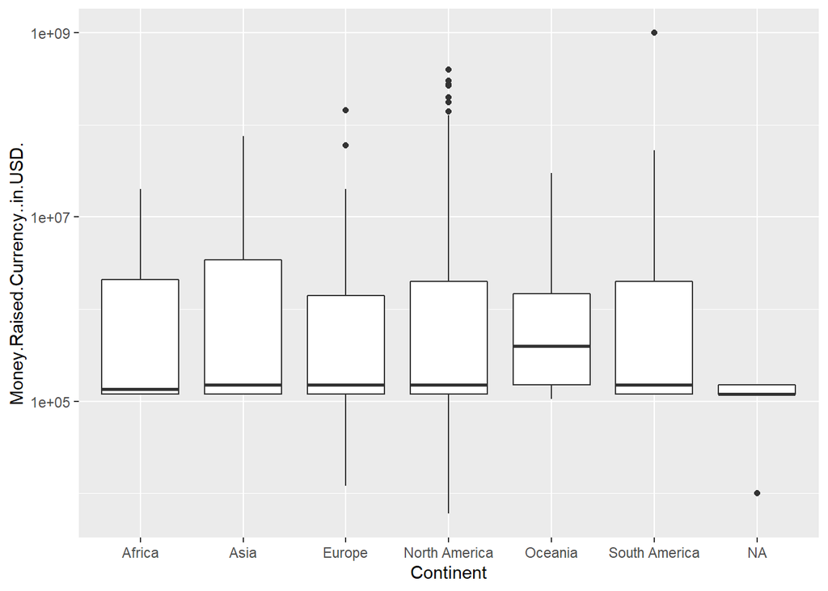

```r
ggplot(yc, aes(x = Continent, y=Money.Raised.Currency..in.USD.))+
  geom_boxplot()+
  scale_y_log10()
```

```r
#Add color and labels
```

```r
yc_in_us<-
  subset(yc, Country=="United States")%>%
  group_by(City)%>%
  summarise(n=n())%>%
  arrange(desc(n))
yc_in_us
```

| City | n |
| --- | --- |
| San Francisco | 1079 |
| New York | 143 |
| Mountain View | 97 |
| Palo Alto | 97 |
| Los Angeles | 40 |
| Brooklyn | 34 |
| San Mateo | 32 |
| Oakland | 31 |
| Boston | 30 |
| Berkeley | 29 |

[output cut: 157 more lines]

#Now let’s explore YC data and money raised

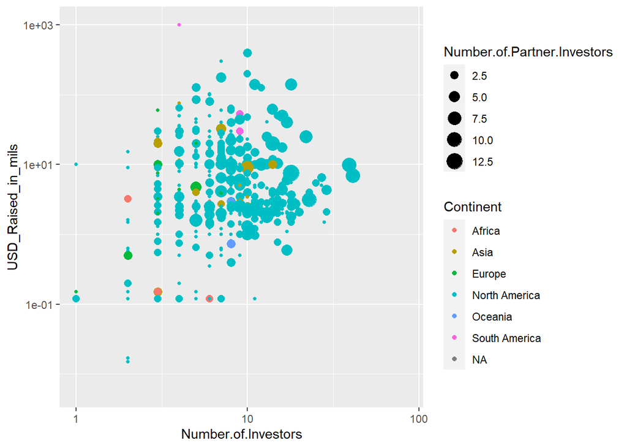

```r
ggplot(yc, aes(Number.of.Investors, USD_Raised_in_mils, size=Number.of.Partner.Investors, color = Continent)) + geom_point()+scale_x_log10() + scale_y_log10()
```

```r
#ggplot(Vocab, aes(x = education, y = vocabulary)) +
 # geom_jitter(alpha = 0.25) +
  # Add a quantile stat, at 0.05, 0.5, and 0.95
  #stat_quantile(quantiles = c(0.05, 0.5, 0.95))
```

#Well Well Well. Seems that not all Unicorns are made the same #btw, put those money in billion, change axis? boxplot or violin plot for money raised v. funding type? #group by continent? linear regression for a train and test so that you put those coefficients in the other dataset? #what about this? Which yc became unicorn v. those who are still not unicorn? chances are to identify and capture an Alicorn we might need to call Prof. Oak for this

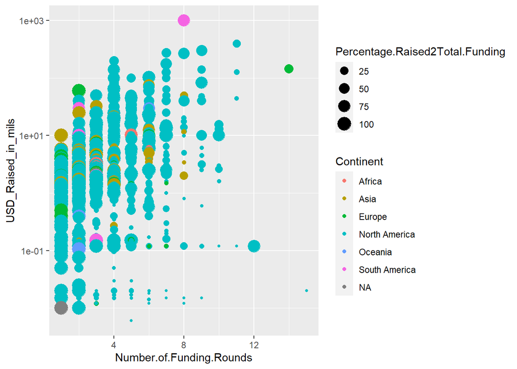

```r
ggplot(yc, aes(Number.of.Funding.Rounds,USD_Raised_in_mils, size=Percentage.Raised2Total.Funding, color = Continent)) + geom_point()+ scale_y_log10()
```

#HOLD ON. Wait a second. That Southamerican point has a story behind. Find out why it looks like an outlier

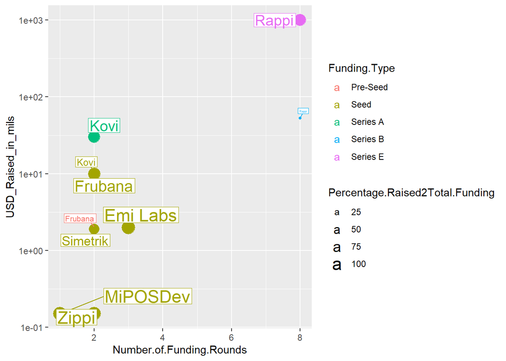

```r
yc_en_sudamerica<-subset(yc, Continent=="South America")%>%
  group_by(State)%>%
  head(n=10)
ggplot(yc_en_sudamerica, aes(Number.of.Funding.Rounds,USD_Raised_in_mils, size=Percentage.Raised2Total.Funding, color= Funding.Type, label = Name)) + geom_point()+ scale_y_log10() + geom_label_repel(min.segment.length = 0.1, max.overlaps = Inf, label.size = 0.1, label.padding = 0.1, label.r = 0)
```

#OH. So companies apply more than one time like little entittled Kovi. Find out those so called american startups

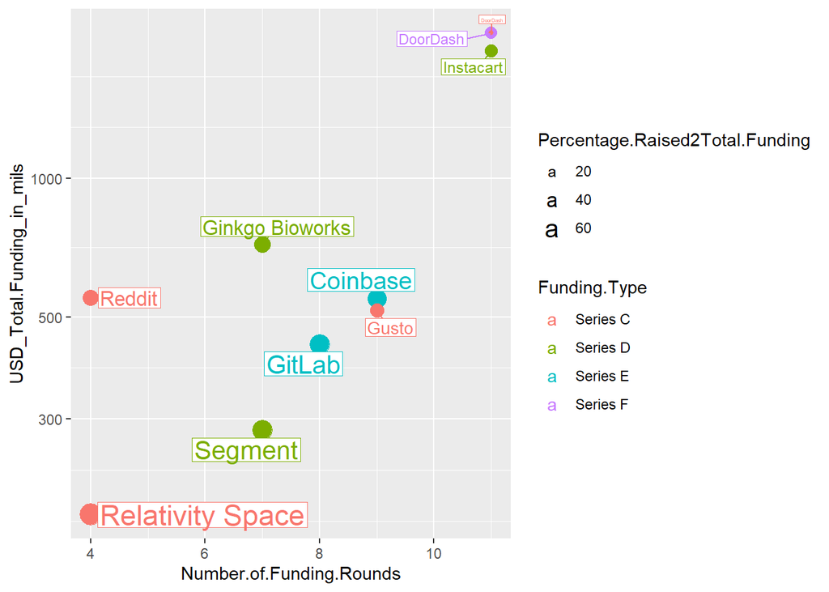

```r
yc_pal_norte <-subset(yc, Continent=="North America")%>%
                        group_by(State)%>%
                        head(n=10)
ggplot(yc_pal_norte, aes(Number.of.Funding.Rounds,USD_Total.Funding_in_mils, size=Percentage.Raised2Total.Funding, color= Funding.Type, label = Name)) + geom_point() +scale_y_log10()+ geom_label_repel(min.segment.length = 0.1, max.overlaps = Inf, label.size = 0.1, label.padding = 0.1, label.r = 0)
```

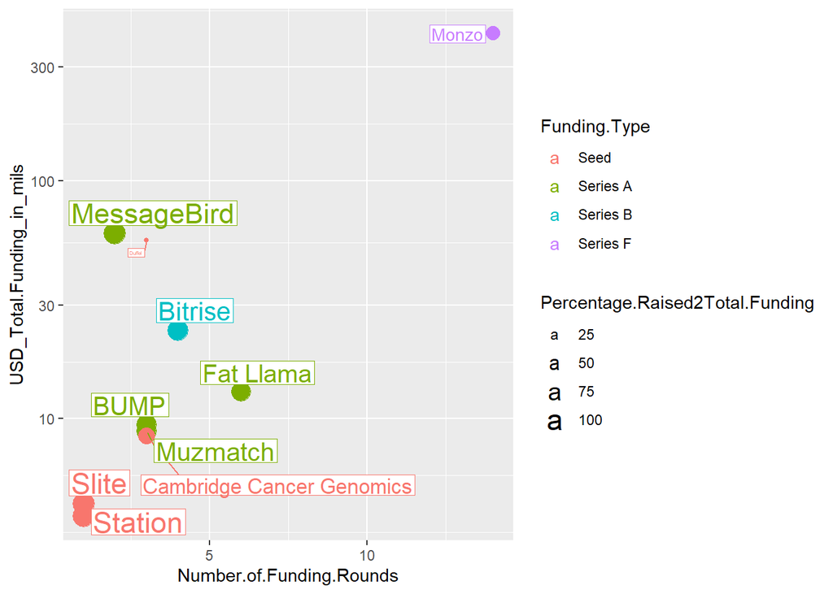

```r
yc_europe <-subset(yc, Continent=="Europe")%>%
                        group_by(State)%>%
                        head(n=10)
ggplot(yc_europe, aes(Number.of.Funding.Rounds,USD_Total.Funding_in_mils, size=Percentage.Raised2Total.Funding, color= Funding.Type, label = Name)) + geom_point() +scale_y_log10()+ geom_label_repel(min.segment.length = 0.1, max.overlaps = Inf, label.size = 0.1, label.padding = 0.1, label.r = 0)
```

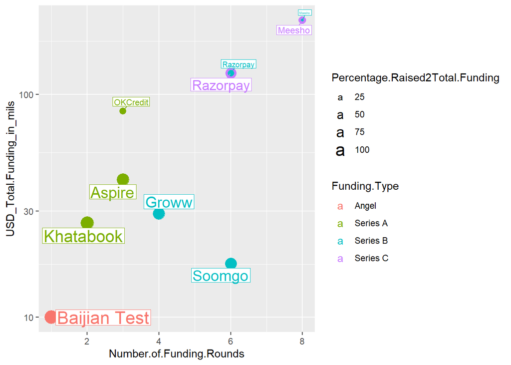

```r
yc_asia <-subset(yc, Continent=="Asia")%>%
                        group_by(State)%>%
                        head(n=10)
ggplot(yc_asia, aes(Number.of.Funding.Rounds,USD_Total.Funding_in_mils, size=Percentage.Raised2Total.Funding, color= Funding.Type, label = Name)) + geom_point() +scale_y_log10()+ geom_label_repel(min.segment.length = 0.1, max.overlaps = Inf, label.size = 0.1, label.padding = 0.1, label.r = 0)
```

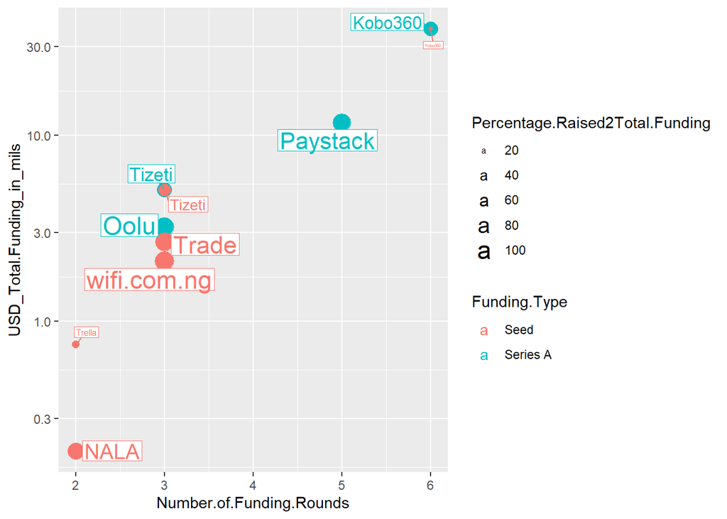

```r
yc_africa <-subset(yc, Continent=="Africa")%>%
                        group_by(State)%>%
                        head(n=10)
ggplot(yc_africa, aes(Number.of.Funding.Rounds,USD_Total.Funding_in_mils, size=Percentage.Raised2Total.Funding, color= Funding.Type, label = Name)) + geom_point() +scale_y_log10()+ geom_label_repel(min.segment.length = 0.1, max.overlaps = Inf, label.size = 0.1, label.padding = 0.1, label.r = 0)
```

# Now let’s explore the average transition in categories

```r
unis <-yc%>%
  group_by(Name)%>%
  filter(Counts==1)
str(unis)
```

```
## grouped_df [72 × 31] (S3: grouped_df/tbl_df/tbl/data.frame)
##  $ Unicorn_Bin                           : int [1:72] 1 1 1 1 1 1 1 1 1 1 ...
##  $ Name                                  : chr [1:72] "Monzo" "Quora" "Convoy" "Reddit" ...
##  $ Count                                 : int [1:72] 1 2 1 3 3 3 2 2 2 2 ...
##  $ Counts                                : int [1:72] 1 1 1 1 1 1 1 1 1 1 ...
##  $ Transaction.Name                      : chr [1:72] "Series F - Monzo" "Series C - Quora" "Series B - Convoy" "Series B - Reddit" ...
##  $ Funding.Type                          : chr [1:72] "Series F" "Series C" "Series B" "Series B" ...
##  $ Money.Raised.Currency..in.USD.        : int [1:72] 143399377 80000000 62000000 50000000 44000000 21400000 10000000 10000000 9999999 9000000 ...
##  $ Announced.Date                        : chr [1:72] "6/25/2019" "4/9/2014" "7/25/2017" "9/30/2014" ...
##  $ Funding.Stage                         : chr [1:72] "Late Stage Venture" "Late Stage Venture" "Early Stage Venture" "Early Stage Venture" ...
##  $ Pre.Money.Valuation.Currency..in.USD. : num [1:72] 2.39e+09 8.20e+08 NA 4.50e+08 3.56e+08 ...
##  $ Description                           : chr [1:72] "Monzo is a London-based digital-only bank platform." "Quora is a Q&A platform with a mission to share and grow the world's knowledge." "Convoy is the most efficient digital freight network." "Reddit is an online platform, enabling its users t…
##  $ Categories                            : chr [1:72] "Fintech" "Internet software & services" "Supply chain, logistics, & delivery" "Internet software & services" ...
##  $ City                                  : chr [1:72] "London" "Mountain View" "Seattle" "San Francisco" ...
##  $ State                                 : chr [1:72] "England" "California" "Washington" "California" ...
##  $ Country                               : chr [1:72] "United Kingdom" "United States" "United States" "United States" ...
##  $ Continent                             : chr [1:72] "Europe" "North America" "North America" "North America" ...
##  $ Website                               : chr [1:72] "https://monzo.com/" "http://quora.com" "https://convoy.com" "http://www.reddit.com" ...
##  $ Revenue.Range                         : chr [1:72] "" "$10M to $50M" "$10M to $50M" "" ...
##  $ Total.Funding.Amount.Currency..in.USD.: num [1:72] 4.17e+08 2.26e+08 6.66e+08 5.50e+08 1.90e+09 ...
##  $ Funding.Status                        : chr [1:72] "Late Stage Venture" "Late Stage Venture" "Late Stage Venture" "M&A" ...
##  $ Number.of.Funding.Rounds              : int [1:72] 14 4 6 4 11 4 5 3 3 2 ...
##  $ Lead.Investors                        : chr [1:72] "Y Combinator" "Tiger Global Management" "Y Combinator" "Y Combinator" ...
##  $ Investor.Names                        : chr [1:72] "Accel, Future Fifty, General Catalyst, Goodwater Capital, Latitude, Orange Digital Ventures, Passion Capital, S"| __truncated__ "Benchmark, Founders Fund, Matrix Partners, North Bridge Venture Partners & Growth Equity, Tiger Global Manageme"|…
##  $ Number.of.Investors                   : int [1:72] 10 6 14 16 9 3 8 5 5 4 ...
##  $ Number.of.Partner.Investors           : int [1:72] NA 3 5 6 4 2 7 1 NA 1 ...
##  $ Years_Transition_Unicorn              : num [1:72] NA 3.04 1.16 2.84 0.54 1.55 5.99 2.07 2.64 1.73 ...
##  $ USD_Pre_Val_in_mils                   : num [1:72] 2395 820 NA 450 356 ...
##  $ USD_Raised_in_mils                    : num [1:72] 143 80 62 50 44 ...
##  $ USD_Total.Funding_in_mils             : num [1:72] 417 226 666 550 1896 ...
##  $ Percentage.Raised2Total.Funding       : num [1:72] 34.36 35.4 9.32 9.09 2.32 ...
##  $ Percentage.Raised2Pre_Val             : num [1:72] 5.99 9.76 NA 11.11 12.36 ...
##  - attr(*, "groups")= tibble [72 × 2] (S3: tbl_df/tbl/data.frame)
##   ..$ Name : chr [1:72] "Ajaib" "Alchemy" "Algolia" "Assembly" ...
##   ..$ .rows: list<int> [1:72]
##   .. ..$ : int 28
##   .. ..$ : int 29
##   .. ..$ : int 50
##   .. ..$ : int 62
##   .. ..$ : int 17
```

[output cut: 54 more lines]

```
##   .. ..$ : int 35
##   .. ..$ : int 54
##   .. ..$ : int 71
##   .. ..$ : int 30
##   .. ..$ : int 37
##   .. ..$ : int 21
##   .. ..$ : int 72
##   .. ..$ : int 60
##   .. ..$ : int 19
##   .. ..$ : int 42
##   .. ..$ : int 23
##   .. ..$ : int 46
##   .. ..$ : int 34
##   .. ..@ ptype: int(0)
##   ..- attr(*, ".drop")= logi TRUE
```

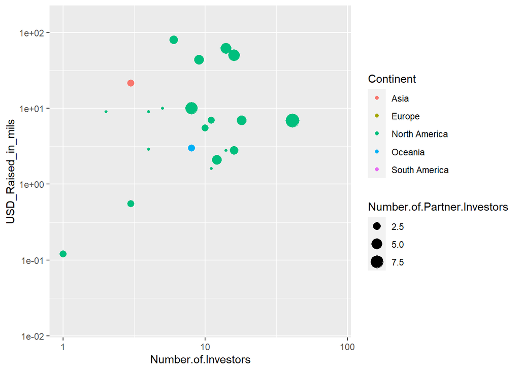

```r
ggplot(unis, aes(Number.of.Investors, USD_Raised_in_mils, size=Number.of.Partner.Investors, color = Continent)) +geom_point()+ scale_x_log10() + scale_y_log10()
```

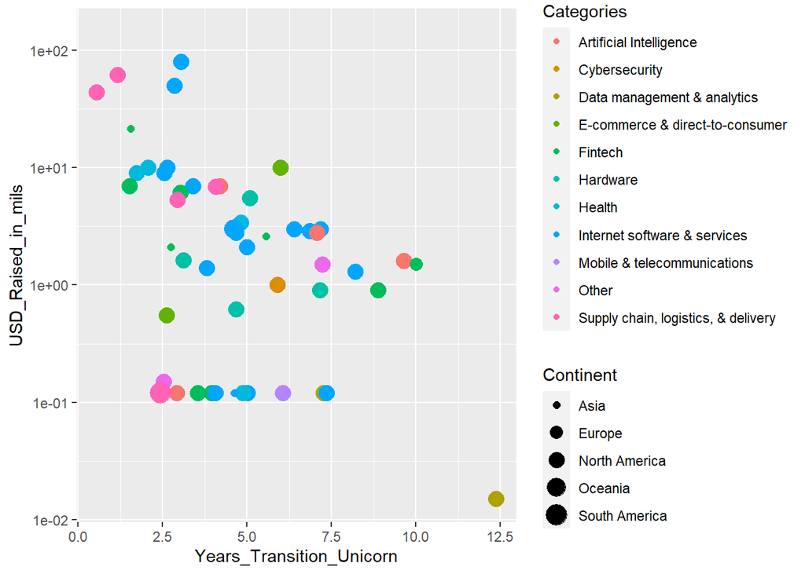

```r
ggplot(unis, aes(Years_Transition_Unicorn, USD_Raised_in_mils,  color = Categories,   size = Continent)) + geom_point() +scale_y_log10()
```

```r
#modelbin3 <- glm(Unicorn  ~ Continent + Revenue + Status + Industry + Valuation + avg_Years_Transition_Unicorn, family = "binomial", data = unis)
#summary(modelbin3)
set.seed(88)
yc_shuffled1 <- yc %>%
  sample_frac(size=1, replace=FALSE)
yc_train1<-yc_shuffled1 %>%
  slice(1:1500)
yc_test1<- yc_shuffled1 %>%
  slice(1501:nrow(yc_shuffled1))
```

```r
modelbin3 <- glm(Unicorn_Bin  ~  Revenue.Range + Funding.Status + Number.of.Funding.Rounds + Total.Funding.Amount.Currency..in.USD., family = "binomial", data = yc_train1)
summary(modelbin3)
```

```
##
## Call:
## glm(formula = Unicorn_Bin ~ Revenue.Range + Funding.Status +
##     Number.of.Funding.Rounds + Total.Funding.Amount.Currency..in.USD.,
##     family = "binomial", data = yc_train1)
##
## Deviance Residuals:
##     Min       1Q   Median       3Q      Max
## -1.5148  -0.2837  -0.1573  -0.1441   3.0239
##
## Coefficients:
##                                          Estimate Std. Error z value Pr(>|z|)
## (Intercept)                            -2.915e+00  5.380e-01  -5.418 6.03e-08
## Revenue.Range$100M to $500M            -6.549e-02  1.166e+00  -0.056   0.9552
## Revenue.Range$10M to $50M               3.265e-01  4.619e-01   0.707   0.4796
## Revenue.Range$1B to $10B                1.572e+01  1.029e+03   0.015   0.9878
## Revenue.Range$1M to $10M                6.295e-01  2.737e-01   2.300   0.0215
## Revenue.Range$500M to $1B               1.615e+01  1.455e+03   0.011   0.9911
## Revenue.Range$50M to $100M              1.412e+00  1.097e+00   1.287   0.1982
## Revenue.RangeLess than $1M             -8.280e-01  7.521e-01  -1.101   0.2710
## Funding.StatusEarly Stage Venture       8.847e-01  4.562e-01   1.939   0.0525
## Funding.StatusIPO                      -1.307e+01  8.167e+02  -0.016   0.9872
## Funding.StatusLate Stage Venture        2.793e+00  5.130e-01   5.444 5.21e-08
## Funding.StatusM&A                      -1.441e+00  8.539e-01  -1.688   0.0915
## Funding.StatusSeed                     -1.383e+00  5.412e-01  -2.556   0.0106
## Number.of.Funding.Rounds               -8.829e-02  7.732e-02  -1.142   0.2535
## Total.Funding.Amount.Currency..in.USD.  4.934e-10  3.623e-10   1.362   0.1732
##
## (Intercept)                            ***
## Revenue.Range$100M to $500M
## Revenue.Range$10M to $50M
## Revenue.Range$1B to $10B
## Revenue.Range$1M to $10M               *
## Revenue.Range$500M to $1B
## Revenue.Range$50M to $100M
## Revenue.RangeLess than $1M
## Funding.StatusEarly Stage Venture      .
## Funding.StatusIPO
## Funding.StatusLate Stage Venture       ***
## Funding.StatusM&A                      .
## Funding.StatusSeed                     *
## Number.of.Funding.Rounds
## Total.Funding.Amount.Currency..in.USD.
## ---
## Signif. codes:  0 '***' 0.001 '**' 0.01 '*' 0.05 '.' 0.1 ' ' 1
##
## (Dispersion parameter for binomial family taken to be 1)
##
##     Null deviance: 726.79  on 1603  degrees of freedom
## Residual deviance: 522.29  on 1589  degrees of freedom
##   (356 observations deleted due to missingness)
## AIC: 552.29
##
## Number of Fisher Scoring iterations: 14
```

```r
modelbin3a <- lm(Unicorn_Bin  ~  Revenue.Range + Funding.Status + Number.of.Funding.Rounds + Total.Funding.Amount.Currency..in.USD., family = "binomial", data = yc_train1)
summary(modelbin3a)
```

```
##
## Call:
## lm(formula = Unicorn_Bin ~ Revenue.Range + Funding.Status + Number.of.Funding.Rounds +
##     Total.Funding.Amount.Currency..in.USD., data = yc_train1,
##     family = "binomial")
##
## Residuals:
##      Min       1Q   Median       3Q      Max
## -0.62531 -0.04590 -0.01097 -0.00703  0.99683
##
## Coefficients:
##                                          Estimate Std. Error t value Pr(>|t|)
## (Intercept)                             4.938e-02  2.414e-02   2.046 0.040969
## Revenue.Range$100M to $500M             4.303e-02  1.149e-01   0.375 0.708078
## Revenue.Range$10M to $50M               1.475e-02  2.844e-02   0.519 0.604151
## Revenue.Range$1B to $10B                5.526e-01  1.569e-01   3.521 0.000443
## Revenue.Range$1M to $10M                3.493e-02  1.325e-02   2.637 0.008445
## Revenue.Range$500M to $1B               5.777e-01  2.145e-01   2.693 0.007153
## Revenue.Range$50M to $100M              2.094e-01  9.897e-02   2.116 0.034505
## Revenue.RangeLess than $1M             -1.190e-02  1.826e-02  -0.652 0.514572
## Funding.StatusEarly Stage Venture       6.286e-02  2.234e-02   2.814 0.004949
## Funding.StatusIPO                      -1.219e-01  1.301e-01  -0.937 0.348790
## Funding.StatusLate Stage Venture        3.860e-01  3.181e-02  12.132  < 2e-16
## Funding.StatusM&A                      -3.039e-02  2.549e-02  -1.192 0.233347
## Funding.StatusSeed                     -3.447e-02  2.144e-02  -1.608 0.108039
## Number.of.Funding.Rounds               -3.939e-03  3.514e-03  -1.121 0.262464
## Total.Funding.Amount.Currency..in.USD.  2.924e-11  2.444e-11   1.197 0.231673
##
## (Intercept)                            *
## Revenue.Range$100M to $500M
## Revenue.Range$10M to $50M
## Revenue.Range$1B to $10B               ***
## Revenue.Range$1M to $10M               **
## Revenue.Range$500M to $1B              **
## Revenue.Range$50M to $100M             *
## Revenue.RangeLess than $1M
## Funding.StatusEarly Stage Venture      **
## Funding.StatusIPO
## Funding.StatusLate Stage Venture       ***
## Funding.StatusM&A
## Funding.StatusSeed
## Number.of.Funding.Rounds
## Total.Funding.Amount.Currency..in.USD.
## ---
## Signif. codes:  0 '***' 0.001 '**' 0.01 '*' 0.05 '.' 0.1 ' ' 1
##
## Residual standard error: 0.2119 on 1589 degrees of freedom
##   (356 observations deleted due to missingness)
## Multiple R-squared:  0.2095, Adjusted R-squared:  0.2025
## F-statistic: 30.07 on 14 and 1589 DF,  p-value: < 2.2e-16
```

```r
get_regression_table(modelbin3a)
```

| term | estimate | std_error | statistic | p_value | lower_ci | upper_ci |
| --- | --- | --- | --- | --- | --- | --- |
| intercept | 0.049 | 0.024 | 2.046 | 0.041 | 0.002 | 0.097 |
| Revenue.Range: $100M to $500M | 0.043 | 0.115 | 0.375 | 0.708 | -0.182 | 0.268 |
| Revenue.Range: $10M to $50M | 0.015 | 0.028 | 0.519 | 0.604 | -0.041 | 0.071 |
| Revenue.Range: $1B to $10B | 0.553 | 0.157 | 3.521 | 0.000 | 0.245 | 0.860 |
| Revenue.Range: $1M to $10M | 0.035 | 0.013 | 2.637 | 0.008 | 0.009 | 0.061 |
| Revenue.Range: $500M to $1B | 0.578 | 0.215 | 2.693 | 0.007 | 0.157 | 0.998 |
| Revenue.Range: $50M to $100M | 0.209 | 0.099 | 2.116 | 0.035 | 0.015 | 0.404 |
| Revenue.Range: Less than $1M | -0.012 | 0.018 | -0.652 | 0.515 | -0.048 | 0.024 |
| Funding.Status: Early Stage Venture | 0.063 | 0.022 | 2.814 | 0.005 | 0.019 | 0.107 |
| Funding.Status: IPO | -0.122 | 0.130 | -0.937 | 0.349 | -0.377 | 0.133 |

[output cut: 5 more lines]

```r
unis_top_20<-unis %>%
  group_by(Name)%>%
  arrange(desc(Total.Funding.Amount.Currency..in.USD.)) %>%
  head(n=20)
unis_top_20
```

| Unicorn_Bin | Name | Count | Counts | Transaction.Name | Funding.Type | Money.Raised.Currency..in.USD. | Announced.Date | Funding.Stage | Pre.Money.Valuation.Currency..in.USD. | Description | Categories | City | State | Country | Continent | Website | Revenue.Range | Total.Funding.Amount.Currency..in.USD. | Funding.Status | Number.of.Funding.Rounds | Lead.Investors | Investor.Names | Number.of.Investors | Number.of.Partner.Investors | Years_Transition_Unicorn | USD_Pre_Val_in_mils | USD_Raised_in_mils | USD_Total.Funding_in_mils | Percentage.Raised2Total.Funding | … |
| --- | --- | --- | --- | --- | --- | --- | --- | --- | --- | --- | --- | --- | --- | --- | --- | --- | --- | --- | --- | --- | --- | --- | --- | --- | --- | --- | --- | --- | --- | --- |
| 1 | Instacart | 3 | 1 | Series B - Instacart | Series B | 44000000 | 6/16/2014 | Early Stage Venture | 356000000 | Instacart delivers groceries and home essentials from a variety of local stores. | Supply chain, logistics, & delivery | San Francisco | California | United States | North America | https://www.instacart.com | $1B to $10B | 1895800000 | Late Stage Venture | 11 | Andreessen Horowitz | Aaron Levie, Adeyemi Ajao, American Express Ventures, Andreessen Horowitz, Augusta Investments LLC (Urizen), Canaan Partners, Khosla Ventures, Sequoia Capital, Y Combinator | 9 | 4 | 0.54 | 356.000 | 44.0000 | 1895.8000 | 2.320919928 | … |
| 1 | Rappi | 3 | 1 | Seed Round - Rappi | Seed | 120000 | 3/22/2016 | Seed | NA | Rappi is a mega high growth, Series E, consumer tech startup looking to be the everything store of Latin America. | Supply chain, logistics, & delivery | Bogotá | Distrito Especial | Colombia | South America | http://www.rappi.com |  | 1392005447 | Late Stage Venture | 8 | Y Combinator | E-Merge, Y Combinator | 2 | NA | 2.44 | NA | 0.1200 | 1392.0054 | 0.008620656 | … |
| 1 | Flexport | 2 | 1 | Series A - Flexport | Series A | 6900000 | 4/1/2014 | Early Stage Venture | NA | Flexport is a full-service global freight forwarder and logistics platform using modern software to fix the user experience in global trade. | Supply chain, logistics, & delivery | San Francisco | California | United States | North America | https://www.flexport.com/ | $100M to $500M | 1304000000 | Late Stage Venture | 6 | Founders Fund | A-Grade Investments, Acequia Capital (Acecap), Alexis Ohanian, Bloomberg Beta, BoxGroup, Cherubic Ventures, Felicis Ventures, First Round Capital, Founders Fund, Fuel Capital, FundersClub, Garry Tan, … | 41 | 9 | 4.08 | NA | 6.9000 | 1304.0000 | 0.529141104 | … |
| 1 | Stripe | 1 | 1 | Seed Round - Stripe | Seed | NA | 8/2/2010 | Seed | NA | Stripe is a global technology company that builds economic infrastructure for the internet. | Fintech | San Francisco | California | United States | North America | https://stripe.com | $500M to $1B | 1035000000 | Late Stage Venture | 11 | Y Combinator | Y Combinator | 1 | NA | 3.48 | NA | NA | 1035.0000 | NA | … |
| 1 | OpenAI | 1 | 1 | Seed Round - OpenAI | Seed | 120000 | 8/22/2016 | Seed | NA | OpenAI is a non-profit artificial intelligence research company that discovers the path to safe artificial general intelligence. | Artificial Intelligence | San Francisco | California | United States | North America | https://www.openai.com/ |  | 1000120000 |  | 2 |  | Y Combinator | 1 | NA | 2.92 | NA | 0.1200 | 1000.1200 | 0.011998560 | … |
| 1 | Convoy | 1 | 1 | Series B - Convoy | Series B | 62000000 | 7/25/2017 | Early Stage Venture | NA | Convoy is the most efficient digital freight network. | Supply chain, logistics, & delivery | Seattle | Washington | United States | North America | https://convoy.com | $10M to $50M | 665500000 | Late Stage Venture | 6 | Y Combinator | Ali Partovi, Bezos Expeditions, Cascade Investment, Counterpart Advisors, Gabriel Naouri, Greylock Partners, Hadi Partovi, Howard Behar, IAC, Jeff Bezos, Marc Benioff, Mosaic Ventures, Red Sea Venture… | 14 | 5 | 1.16 | NA | 62.0000 | 665.5000 | 9.316303531 | … |
| 1 | Reddit | 3 | 1 | Series B - Reddit | Series B | 50000000 | 9/30/2014 | Early Stage Venture | 450000000 | Reddit is an online platform, enabling its users to submit links, create content, and have discussions about the topics of their interest. | Internet software & services | San Francisco | California | United States | North America | http://www.reddit.com |  | 550100000 | M&A | 4 | Y Combinator | 500 Startups, A.Capital Ventures, Andreessen Horowitz, Jared Leto, Jessica Livingston, Kevin Hartz, Mariam Naficy, Paul Buchheit, Philip Kaplan, Rick Marini, Sequoia Capital, Snoop Dogg, SV Angel, Thr… | 16 | 6 | 2.84 | 450.000 | 50.0000 | 550.1000 | 9.089256499 | … |
| 1 | Gusto | 2 | 1 | Seed Round - Gusto | Seed | 6100000 | 12/11/2012 | Seed | NA | Gusto provides a cloud-based payroll, benefits, and human resource management solution for businesses. | Fintech | San Francisco | California | United States | North America | https://www.gusto.com/ | $50M to $100M | 516100000 | Late Stage Venture | 9 |  | 137 Ventures, Aaron Levie, Aaron Patzer, Adam Nash, Aditya Agarwal, Alex Bard, Alexis Ohanian, Ari Emanuel, Arjun Sethi, Ashton Kutcher, Aspect Ventures, Aston Motes, Bobby Yazdani, CapitalG, Charlie … | 85 | NA | 3.02 | NA | 6.1000 | 516.1000 | 1.181941484 | … |
| 1 | Monzo | 1 | 1 | Series F - Monzo | Series F | 143399377 | 6/25/2019 | Late Stage Venture | 2394642700 | Monzo is a London-based digital-only bank platform. | Fintech | London | England | United Kingdom | Europe | https://monzo.com/ |  | 417342054 | Late Stage Venture | 14 | Y Combinator | Accel, Future Fifty, General Catalyst, Goodwater Capital, Latitude, Orange Digital Ventures, Passion Capital, Stripe, Thrive Capital, Y Combinator | 10 | NA | NA | 2394.643 | 143.3994 | 417.3421 | 34.360155088 | … |
| 1 | Brex | 5 | 1 | Series A - Brex | Series A | 7000000 | 4/1/2017 | Early Stage Venture | NA | Brex is the first corporate card for startups, tech, and online brands. | Fintech | San Francisco | California | United States | North America | https://brex.com |  | 382120000 | Late Stage Venture | 7 | Ribbit Capital | ArpexCapital, Caffeinated Capital, Elad Gil, Exor Seeds, GE32 Capital, Jake Seid, Max Levchin, Michael Seibel, Paul Buchheit, Peter Thiel, Ribbit Capital, Ruchi Sanghvi, Y Combinator | 13 | NA | 1.51 | NA | 7.0000 | 382.1200 | 1.831885272 | … |

[output cut: 10 more lines]

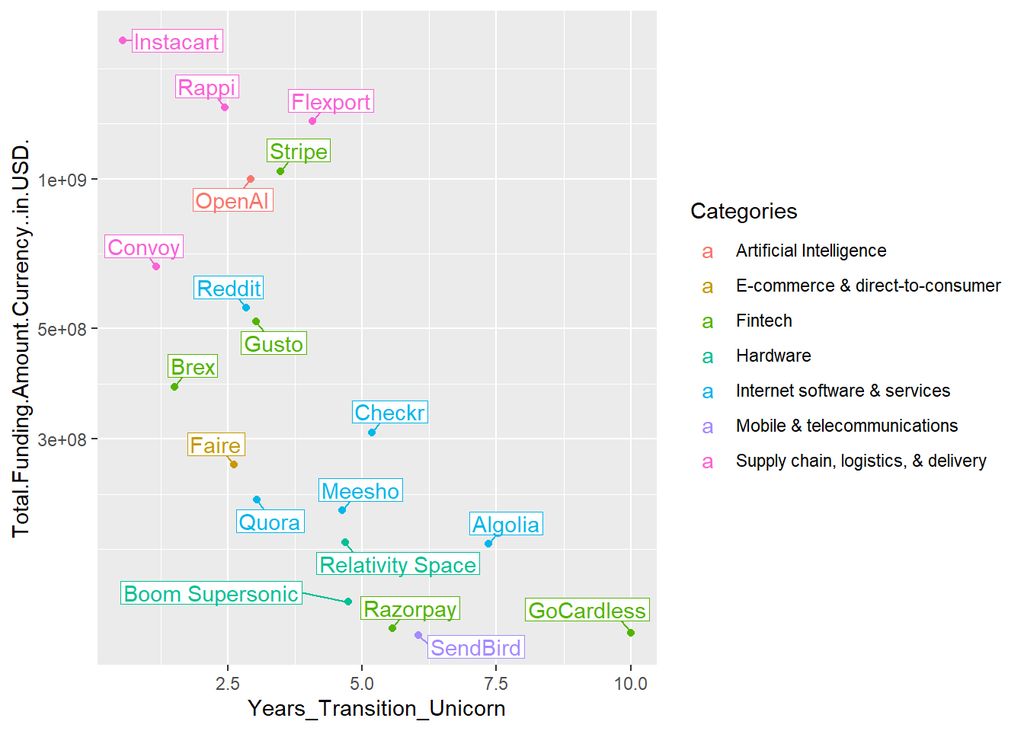

```r
ggplot(unis_top_20, aes(Years_Transition_Unicorn,Total.Funding.Amount.Currency..in.USD., color = Categories, label = Name)) + geom_point()+scale_y_log10()+ geom_label_repel(min.segment.length = 0.1, max.overlaps = Inf, label.size = 0.1, label.padding = 0.1, label.r = 0)
```

```r
model_1<- lm(Number.of.Funding.Rounds~USD_Total.Funding_in_mils, data= yc)
get_regression_table(model_1)
```

| term | estimate | std_error | statistic | p_value | lower_ci | upper_ci |
| --- | --- | --- | --- | --- | --- | --- |
| intercept | 2.965 | 0.041 | 72.369 | 0 | 2.884 | 3.045 |
| USD_Total.Funding_in_mils | 0.003 | 0.000 | 17.492 | 0 | 0.003 | 0.003 |

```r
get_regression_points(model_1) %>%
summarize(r_squared= 1-var(model_1$residual)/ var(yc$Number.of.Funding.Rounds))
```

| r_squared |
| --- |
| 0.08247826 |

#Impressive. Very impressive. Let’s see Paul Allen’s model_1a

```r
ymca <-yc%>%
  group_by(Continent)%>%
  summarize(avg_value = mean(USD_Total.Funding_in_mils), n=n())%>%
  arrange(desc(avg_value))
ymca$Continent <-factor(ymca$Continent)



model_1a <-lm(Number.of.Funding.Rounds~USD_Total.Funding_in_mils + Continent , data= yc)
get_regression_table(model_1a)
```

| term | estimate | std_error | statistic | p_value | lower_ci | upper_ci |
| --- | --- | --- | --- | --- | --- | --- |
| intercept | 3.250 | 0.340 | 9.554 | 0.000 | 2.582 | 3.917 |
| USD_Total.Funding_in_mils | 0.003 | 0.000 | 17.457 | 0.000 | 0.003 | 0.003 |
| Continent: Asia | -0.136 | 0.380 | -0.357 | 0.721 | -0.880 | 0.609 |
| Continent: Europe | -0.358 | 0.395 | -0.905 | 0.365 | -1.132 | 0.417 |
| Continent: North America | -0.284 | 0.343 | -0.828 | 0.408 | -0.956 | 0.389 |
| Continent: Oceania | 0.326 | 0.741 | 0.440 | 0.660 | -1.128 | 1.780 |
| Continent: South America | -0.509 | 0.524 | -0.971 | 0.332 | -1.536 | 0.519 |

```r
get_regression_points(model_1a)%>%
summarize(r_squared= 1-var(model_1a$residual)/ var(yc$Number.of.Funding.Rounds))
```

| r_squared |
| --- |
| 0.08392257 |

#This reminds me of Star Wolf ,,you good but I’m betta.” Let’s do a train ’n test to salvage data

```r
set.seed(88)
yc_shuffled <- yc %>%
  sample_frac(size=1, replace=FALSE)
yc_train<-yc_shuffled %>%
  slice(1:2000)
yc_test<- yc_shuffled %>%
  slice(2001:nrow(yc_shuffled))
train_model1<- lm(Number.of.Funding.Rounds~USD_Total.Funding_in_mils + Continent , data= yc_train)
get_regression_table(train_model1)
```

| term | estimate | std_error | statistic | p_value | lower_ci | upper_ci |
| --- | --- | --- | --- | --- | --- | --- |
| intercept | 3.250 | 0.342 | 9.513 | 0.000 | 2.580 | 3.920 |
| USD_Total.Funding_in_mils | 0.003 | 0.000 | 16.988 | 0.000 | 0.003 | 0.003 |
| Continent: Asia | -0.135 | 0.381 | -0.354 | 0.724 | -0.883 | 0.613 |
| Continent: Europe | -0.357 | 0.397 | -0.900 | 0.368 | -1.135 | 0.421 |
| Continent: North America | -0.268 | 0.345 | -0.776 | 0.438 | -0.943 | 0.408 |
| Continent: Oceania | 0.326 | 0.745 | 0.438 | 0.661 | -1.134 | 1.787 |
| Continent: South America | -0.498 | 0.526 | -0.946 | 0.344 | -1.530 | 0.534 |

```r
get_regression_points(train_model1, newdata=yc_test)%>%
  summarize(r_squared= 1-var(train_model1$residual)/ var(yc$Number.of.Funding.Rounds))
```

```
## `mutate_if()` ignored the following grouping variables:
```

| r_squared |
| --- |
| 0.07612778 |

#Well Well Well. Seems that not all Unicorns are made the same #btw, put those money in billion, change axis? boxplot or violin plot for money raised v. funding type? #group by continent? linear regression for a train and test so that you put those coefficients in the other dataset? #what about this? Which yc became unicorn v. those who are still not unicorn? chances are to identify and capture an Alicorn we might need to call Prof. Oak for this

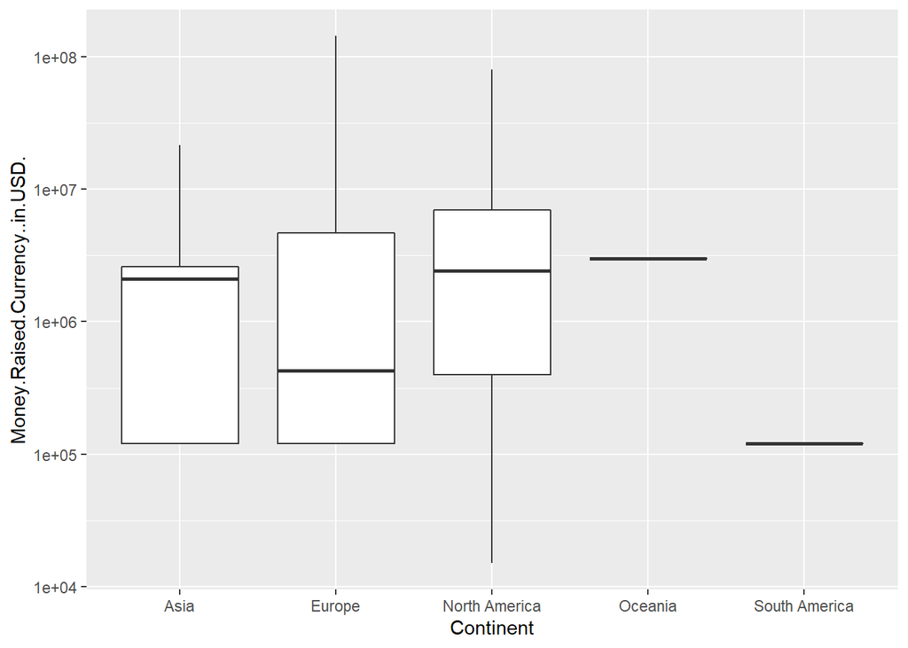

```r
ggplot(unis, aes(x = Continent, y=Money.Raised.Currency..in.USD.))+
  geom_boxplot()+
  scale_y_log10()
```